# daily wow tag quicklook update

wrc

2024-10-08

# 1 NOTES

additional diagnostics:

- detailed look at tx info

# 2 setup

Run this daily to get a snapshot of tag stats and health

## 2.1 PATH TO LATEST DATA

```r
# paths to update when you run
portaldir <- "../../01_data/portal_downloads_2024/"
metadatapath <- "../../01_data/quicklookmeta.csv"
datadirss <- list.files(portaldir)
datadir <- file.path(portaldir, datadirss[length(datadirss)])
```

## 2.2 basic helper function

## 2.3 load paths adjust as needed

## 2.4 Import data from wildlife portal and the goniometer. Merge the two stacks.

disabled still need goniometer from second boat

# 3 tag summary

|  | ptt | hex | serial | tag_model | deployid | catalog_ID_DUML | WOW_season | deploydate_yyyymmdd | deploytime_hhmm_local | deploytime_hhmm_utc | species | location | tagger | permit | tagtype | longitude | latitude | tagside | taglocation | taglocationnotes | programming_basic_descriptor | notes | recorder | age | sex | agesex_conf | headshot | agesex_reason | appearance_notes |
| --- | --- | --- | --- | --- | --- | --- | --- | --- | --- | --- | --- | --- | --- | --- | --- | --- | --- | --- | --- | --- | --- | --- | --- | --- | --- | --- | --- | --- | --- |
| 12 | 265389 | NA |  | SPLASH10-333 | BpTag04 |  | WOW2 | 20240727 | 803 | 1203 | Bph | NYB |  | Nowacek | NA | 39.84151 | -73.16891 | NA | NA | NA | NA |  | NA | NA | NA | NA | NA | NA | NA |
| 13 | 265390 | NA |  | SPLASH10-333 | BpTag05 |  | WOW2 | 20240727 | 937 | 1337 | Bph | NYB |  | Nowacek | NA | 39.86678 | -73.11247 | NA | NA | NA | NA |  | NA | NA | NA | NA | NA | NA | NA |
| 14 | 265393 | NA |  | SPLASH10-333 | BpTag06 |  | WOW2 | 20240727 | 1005 | 1405 | Bph | NYB |  | Nowacek | NA | 39.86257 | -73.10954 | NA | NA | NA | NA |  | NA | NA | NA | NA | NA | NA | NA |
| 15 | 265392 | NA |  | SPLASH10-333 | BpTag07 |  | WOW2 | 20240728 | 1118 | 1518 | Bph | NYB |  | Nowacek | NA | 39.84278 | -73.09850 | NA | NA | NA | NA |  | NA | NA | NA | NA | NA | NA | NA |
| 16 | 265394 | NA |  | SPLASH10-333 | BpTag08 |  | WOW2 | 20240728 | 1403 | 1803 | Bph | NYB |  | Nowacek | NA | 39.85375 | -73.10134 | NA | NA | NA | NA |  | NA | NA | NA | NA | NA | NA | NA |
| 10 | 265395 | NA | 24U2337 | SPOT6-365 | MnTag05 | NYB208 | WOW2 | 20240708 | 1459 | 1859 | Mno | NYB |  | Nowacek | NA | 39.72330 | -73.11563 | NA | NA | NA | NA |  | NA | NA | NA | NA | NA | NA | NA |
| 11 | 265396 | NA | 24U2339 | SPOT6-365 | MnTag06 | NYB209 | WOW2 | 20240708 | 1555 | 1955 | Mno | NYB |  | Nowacek | NA | 39.77591 | 73.15733 | NA | NA | NA | NA | never pinged before or after deployed; only 1 dart in animal | NA | NA | NA | NA | NA | NA | NA |

# 4 calculate stats

# 5 summaries

## 5.1 status and corrupt

| deployid | ptt | nmsg | ncrc | transmits | battvoltrange | zerodepthrange | last_sta_recieved | ncorrupt |
| --- | --- | --- | --- | --- | --- | --- | --- | --- |
| BpTag04 | 265389 | 7 | 6 | 1352 | 3.504 to 3.504 | 0.5 to 1.5 | 2024-08-03 22:57:15 | 181 |
| BpTag05 | 265390 | 17 | 13 | 5441 | 3.44 to 3.504 | 1 to 2 | 2024-08-05 11:35:26 | 234 |
| BpTag06 | 265392 | 3 | 3 | 1355 | 3.568 to 3.568 | 1 to 1.5 | 2024-08-22 16:28:29 | 79 |
| BpTag07 | 265393 | 8 | 8 | 4673 | 3.376 to 3.44 | 1 to 1.5 | 2024-08-02 16:37:17 | 138 |
| BpTag08 | 265394 | 2 | 1 | NA | Inf to -Inf | 1 to 1 | 2024-07-31 10:32:43 | 65 |
| MnTag05 | 265395 | 285 | 10 | 1883 | 3.45 to 3.55 | Inf to -Inf | 2024-07-12 16:15:18 | 33 |

## 5.2 locations

| deployid | ptt | nloc | nz | na | nb | n0 | n1 | n2 | n3 | last_loc_recieved |
| --- | --- | --- | --- | --- | --- | --- | --- | --- | --- | --- |
| BpTag04 | 265389 | 182 | 3 | 27 | 123 | 22 | 6 | 1 | 0 | 2024-08-04 00:07:00 |
| BpTag05 | 265390 | 226 | 0 | 34 | 126 | 50 | 15 | 1 | 0 | 2024-08-05 18:13:18 |
| BpTag06 | 265392 | 75 | 1 | 3 | 70 | 1 | 0 | 0 | 0 | 2024-08-30 23:13:18 |
| BpTag07 | 265393 | 139 | 0 | 20 | 98 | 18 | 3 | 0 | 0 | 2024-08-02 17:55:02 |
| BpTag08 | 265394 | 68 | 2 | 12 | 43 | 8 | 2 | 1 | 0 | 2024-07-31 15:35:15 |
| MnTag05 | 265395 | 101 | 6 | 14 | 42 | 37 | 2 | 0 | 0 | 2024-07-12 16:12:24 |

## 5.3 behavior

n/a

## 5.4 series

disabled for now

## 5.5 fastloc

n/a

# 6 position snapshot

Plot of the last four positions for all the tags which have generated an argos position within the last 3 days

[interactive chart not shown]

# 7 plot pressure sensors

**PROVISIONAL** plot status cutoffs and bat voltage. Cutoffs are in dotted red lines. These are either:

1. healthy tags: the last status messages as a conservative cutoff and on tags that are still actively transmitting this is likely to increase
2. unhealthy pressure transducer tags: if there are 2 status messages (crc’d) where the | zerodepth | > 10 then this is the last good status message before the 1st of those two bad messages.

We have settled on a more complicated cutoff system to capture a little more very likely good data for BRS (ask wrc for details). But this gives you a general idea of approx. cutoffs and pressure transducer health.

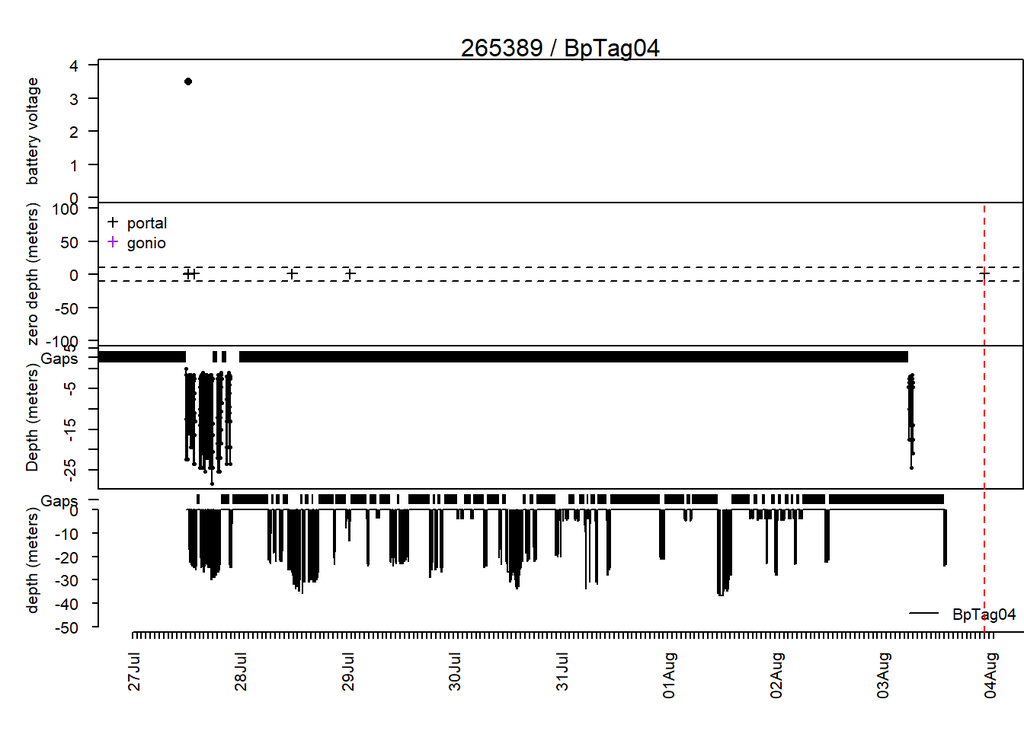

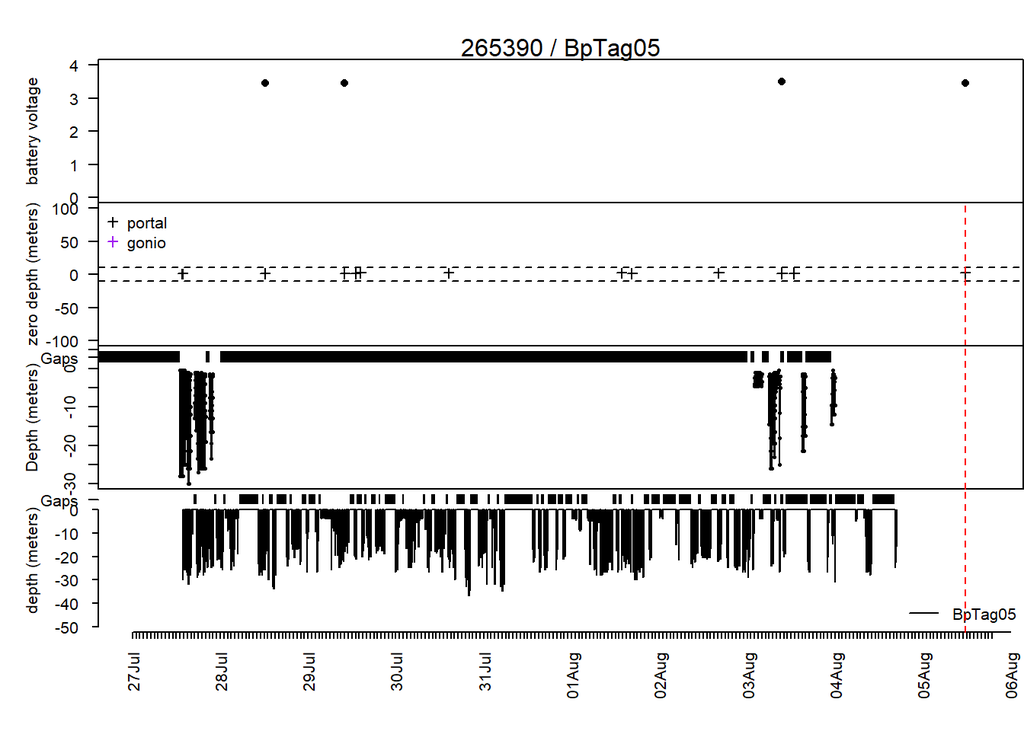

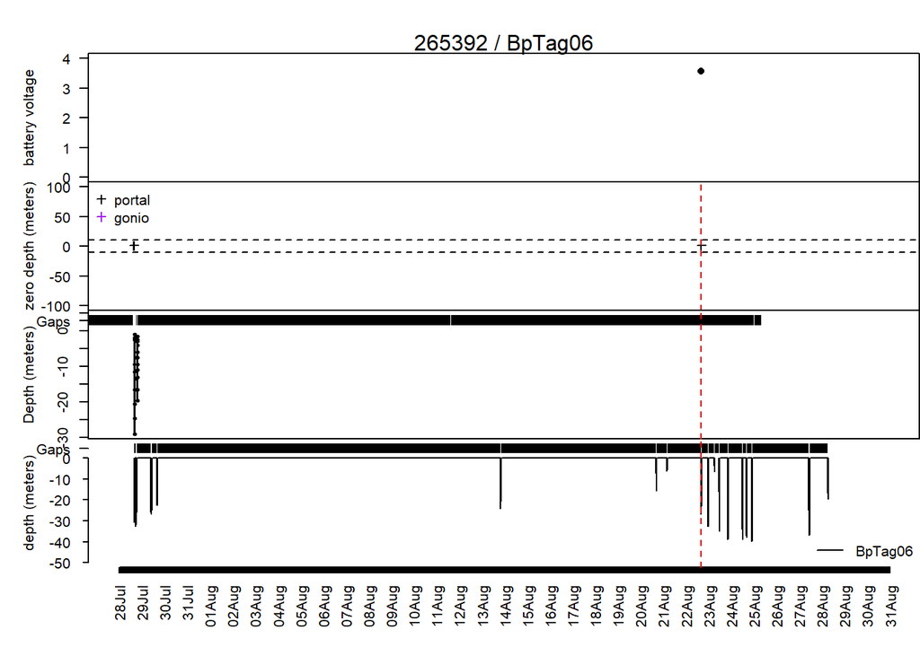

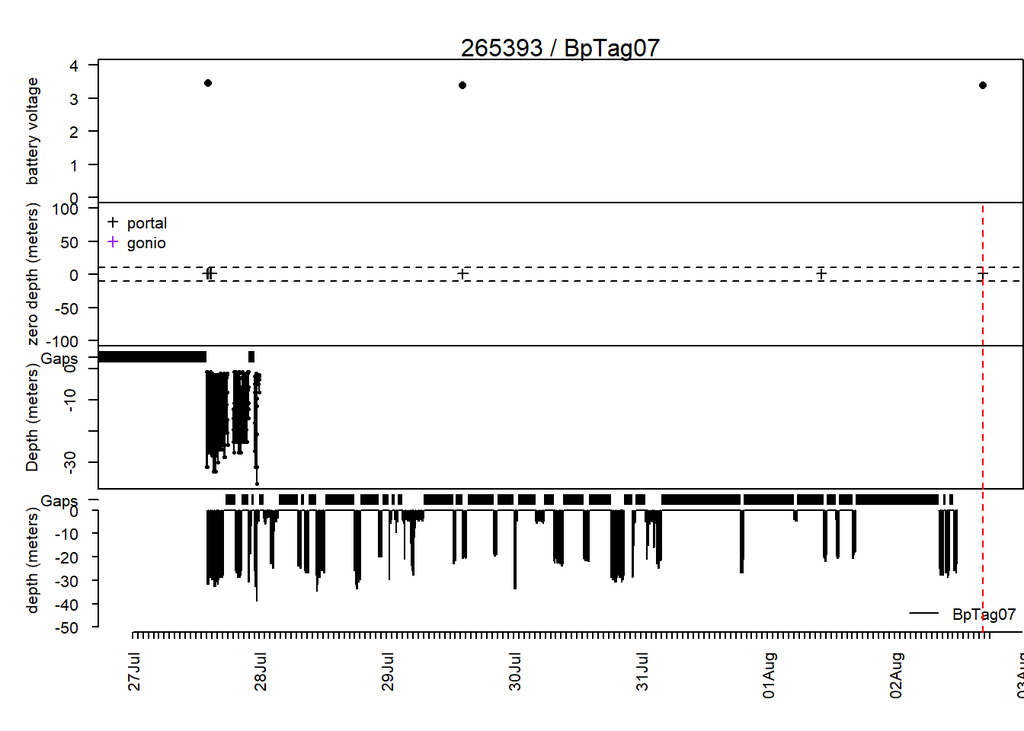

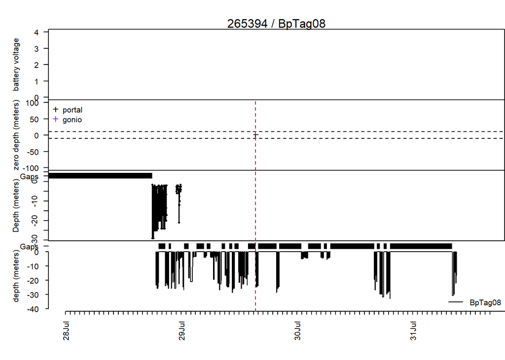

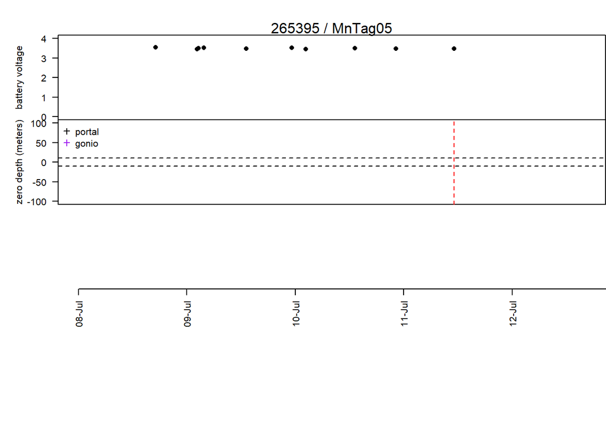

# 8 all positions

‘all’ = just qual = {0, 1, 2, 3} except for bp01 because it only hit As and Bs.

[interactive chart not shown]